# Analisis simple de tendencia

Ishiba RO

2022-09-25

# Introducción

En 19 de septiembre de 1985 un sismo asoló la ciudad de México. Si bien no ha sido el sismo más fuerte que se ha registrado en el país, sí ha sido uno de los más devastadores. Desde entonces se desarrolló un sistema de detección temprana de sismos que se impulsó desde Asociación Civil Cires (CIRES (2012)), es decir el Centro de Instrumentación y Registro Sísmico. Lo que pasó después es que se creó una alerta sísmica que evolucionó en el Sistema de Alerta Sísmica Mexicano SASMEX® [https://www.infosismosmx.com/sasmex]. El 19 de septiembre de 2017, contro todo pronóstico y después del terremoto del 7 de septiembre del mismo año, un nuevo sismo sacudió la capital mexicana reavivando el terror vivido en 1985. Este año, nuevamente contra todo pronóstico, minutos después del Simualcro Nacional 2022 [http://www.preparados.gob.mx/simulacronacional2022/], un nuevo movimiento telúrico le movió el tapete a los chilangos y comenzaron a circular memes, noticias y preguntas acerca de la recursividad de los terremotos de gran magnitud en la ciudad. Siendo septiembre el mes patrio y coincidentemente el mes que acumula el récord de desastres relacionados con los movimientos de la tierra (1985 y 2017), la pregunta que muchos se hacen es, ¿tiembla más fuerte en septiembre? La respuesta inmediata, fundada en la memoria histórica e histérica de los habitantes de la ciudad de México, que apela, entre otras cosas, al realismo mágico mexicano y la chota, apunta a una correlación entre el mes y los temblores, al menos los que sentimos de facto y de jure (¡alerta sísmica! dixit) y nos espantan. La respuesta cientificista semi oficial (SSN-UNAM) es que no existe tal correlación porque no existen datos para validar tal barbaridad. Sin embargo, científicamente, si no hay datos tampoco se puede descartar tal barbaridad. Por lo tanto, ¿se puede analizar una posible tendencia y correlación entre la actividad sísmica en México y el mes en que ocurre? ¿Hay meses más movidos que otros? ¿Hay meses en que podría aumentar la intensidad de los sismos? De modo que se pueda dar una respuesta más cordial y menos arrogante, este ejercicio que presento a continuación intenta contestar a estas interrogantes.

# Datos

## *Catalogo de Sismos*

Comenzamos por descargar el catálogo de sismos en México desde la página Servicio Sismológico Nacional (México) [http://www2.ssn.unam.mx:8080/catalogo/]. Posteriormente cargamos esta tabla en R. Las primeras 4 líneas contienen una descripción de la tabla, así que las vamos a descartar cuando carguemos la tabla en R. La tabla que usé para este análisis la obtuve el 21 de septiembre de 2022.

```r
sismos <- read.csv(
            "datos/SSNMX_catalogo_19000101_20220921.csv",
            skip=4,
            header=TRUE,
            fill=TRUE)
```

Este catálogo está disponible en línea; se agradece a todo el personal del SSN pues gracias al producto de los cálculos realizados por su área de Análisis e Interpretación de Datos Sísmicos tenemos esta gran base de datos nuestra disposición (México et al. (2022)). Esta tabla de datos contiene 260475 registros. El registro más antiguo está fechado el día 1900-01-20. No todos los sismos tienen la magnitud registrada por lo que se han omitido 17649 registros identificados como Magnitud= “no calculable”, con lo que nos queda un registro hasta el día de 21 de septiembre de 2022 de 242826.

Antes de proseguir, debemos darle formato a nuestra tabla, para poder ver las estadísticas básicas

```
##         Fecha Magnitud Latitud Longitud Profundidad
## 55 1932-06-03      8.2   19.57  -104.42          33
```

Ahora bien, vamos a ver desde 1957, año en que ocurrió el sismo que también hizo estragos en la ciudad de México antes de 1985, cuáles han sido los sismos más fuerte (mayores a 7.5 de magnitud), su fecha y profundidad.

```r
sf75 <- sismos_formateado %>%
  dplyr::filter(Fecha > "1957-01-01") %>%
  filter(Magnitud > 7.5) %>%
  arrange(Fecha) %>%
  subset(select = -c(Latitud,
                     Longitud))
```

Y finalmente vamos a mapearlos:

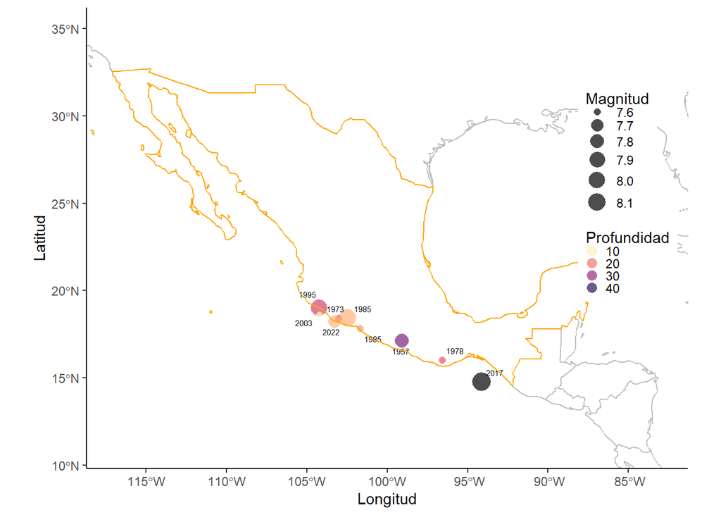

Sismos desde 1957 mayores a 7.5 de magnitud. La profundidad está en kilómetros

## *Ubicación e intensidad de los sismos*

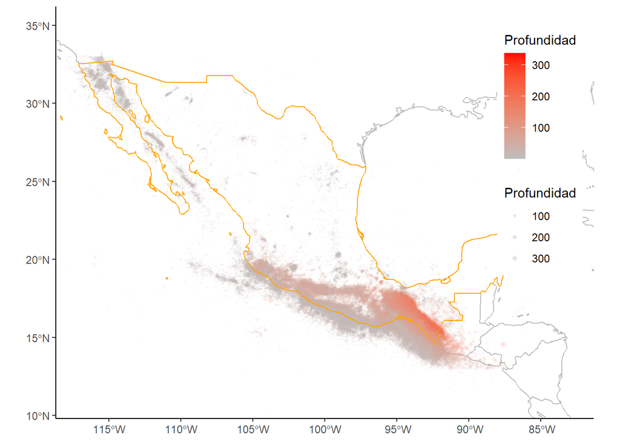

Sismos desde 1901 por Profundidad

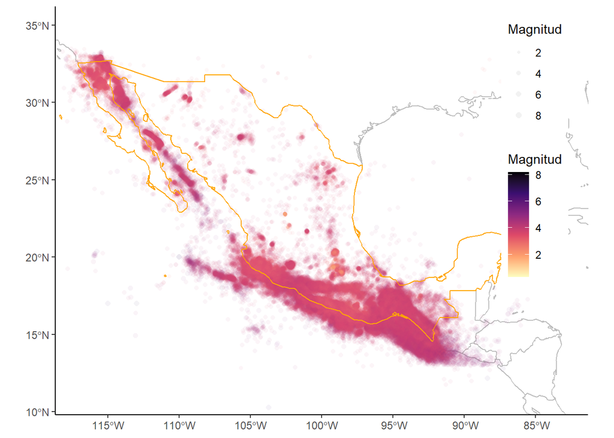

Sismos desde 1901 por magnitud

También podrías mapear sólo las magnitudes mayores a 5, que comúnmente son las que percibimos como humanos.

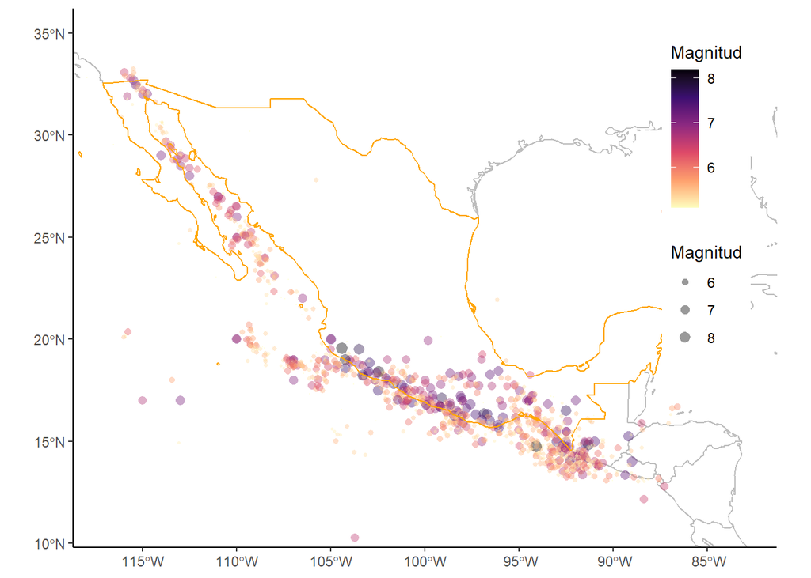

Sismos desde 1901 por magnitud

# Análisis

## *Promedios mensuales por años*

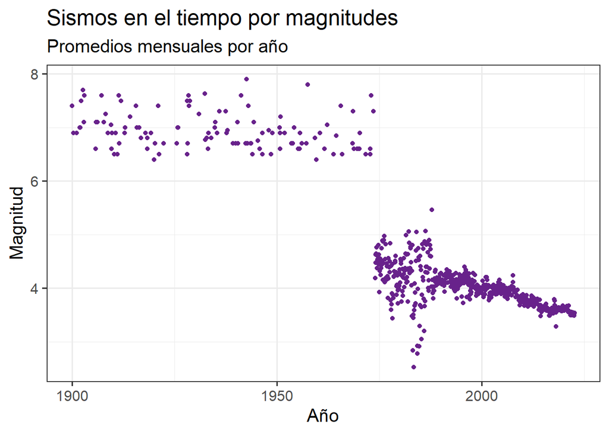

Sismos desde 1901 por magnitud (Promedios mensuales)

Entonces lo que haré será repetir la gráfica pero filtraré los años anteriores a 1988.

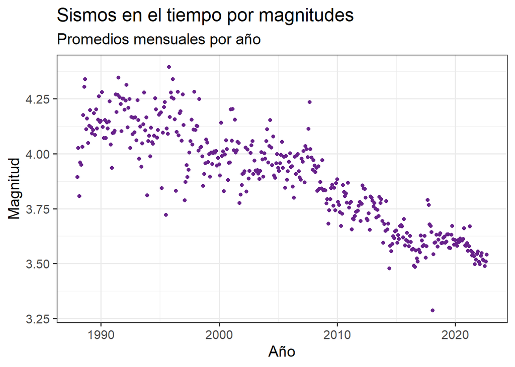

Como podemos ver, desde 1988 ha bajado el promedio de la magnitud pero para poder analizar las tendencias mensuales quizá una mejor forma de ver los datos es agrupándolos por año, como líneas y usando los meses como escala de tiempo.

Primero creamos un data.frame que contendrá los meses en formato texto.

```r
meses <- data.frame ("mesNombre"=c("Enero",
                                   "Febrero",
                                   "Marzo",
                                   "Abril",
                                   "Mayo",
                                   "Junio",
                                   "Julio",
                                   "Agosto",
                                   "Septiembre",
                                   "Octubre",
                                   "Noviembre",
                                   "Diciembre"),
                     "messolo"=c(1,2,3,4,5,6,7,8,9,10,11,12))
```

Luego procesamos nuestros datos de modo que combinemos esta información con el promedio mensual.

```r
ladob<-sismos_puntos %>%
    dplyr::filter(Fecha > "1988-01-01") %>%
    group_by(mes = lubridate::floor_date(Fecha, 'month')) %>%
    summarize(magPromedio = mean(Magnitud)) %>%
    st_drop_geometry() %>%
    as_tibble() %>%
    mutate(anyo = lubridate::year(mes),
           messolo = lubridate::month(mes))
```

Finalmente hacemos la unión

```r
datosGrafico <- merge(x=meses,y=ladob,by="messolo") %>%
                  mutate(
                    mesNombre =
                        factor(.$mesNombre,
                               levels=meses$mesNombre),
                        magPromedio =
                          if_else(anyo==2022,
                                  max(abs(magPromedio)),
                                  magPromedio)
                    )
```

Y usamos este data.frame para hacer nuestra gráfica

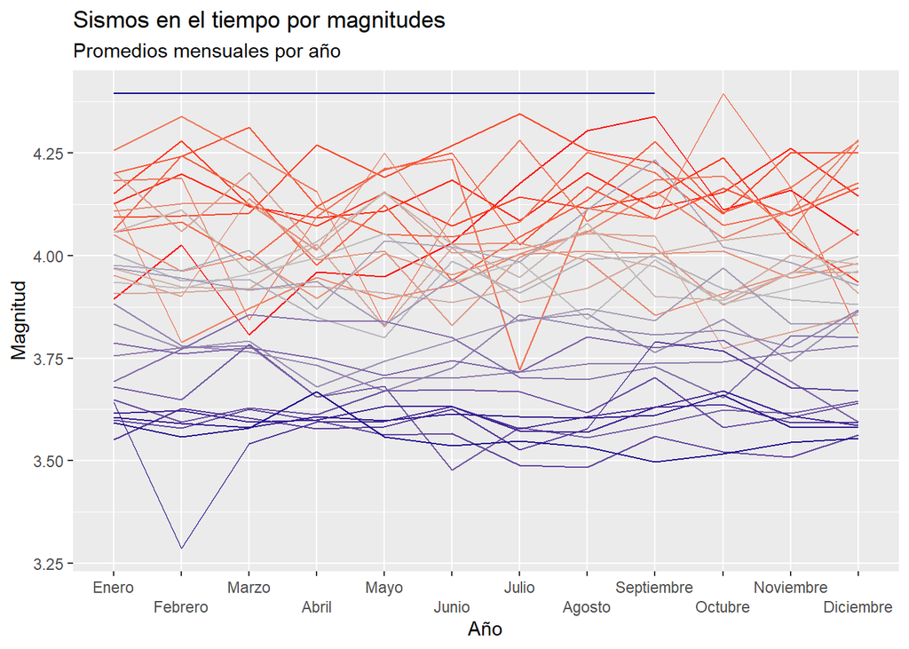

## *Sumatoria de los promedios mensuales por años*

Hagamos el ejercicio anterior pero con los sismos mayores a 5 de magnitud y hagamos todo junto.

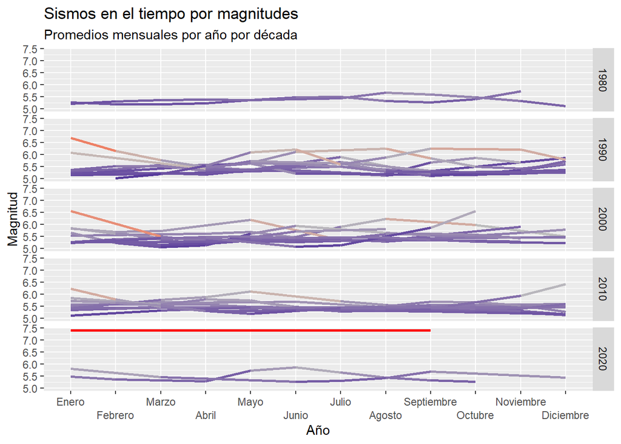

Sismos en el tiempo por magnitudes según década

```r
# procesamos datos para combinar información
# con el promedio mensual y filtramos magnitudes
ladoc <- sismos_puntos %>%
            filter(Magnitud>5) %>%
            dplyr::filter(Fecha > "1988-01-01") %>%
            group_by(mes = lubridate::floor_date(Fecha, 'month')) %>%
            summarize(magPromedio = mean(Magnitud)) %>%
            st_drop_geometry() %>%
            as_tibble() %>%
            mutate(anyo = lubridate::year(mes),
                   messolo = lubridate::month(mes))
#unimos datos y creamos columnas adicionales
datosGrafico5mas <- merge(x=meses,y=ladoc,by="messolo") %>%
                    mutate(
                      mesNombre =
                            factor(.$mesNombre,
                                  levels=meses$mesNombre),
                      magPromedio =
                            if_else(anyo==2022,
                                    max(abs(magPromedio)),
                                    magPromedio))

#producimos gráfica y la facetamos por décadas
datosGrafico5mas %>%
    mutate(decada= anyo-anyo %% 10) %>%
    ggplot(aes(x = mesNombre, y = magPromedio, group=anyo, color=magPromedio)) +
    geom_smooth(aes(color=..y..), size=1, se=FALSE) +
    scale_color_gradient2(low="darkblue",
                          mid="grey",
                          high="red",
                          midpoint =6,
                          guide = "none") +
    scale_x_discrete(guide = guide_axis(n.dodge=2))+
    labs(title = "Sismos en el tiempo por magnitudes",
         subtitle = "Promedios mensuales por año por década",
         y = "Magnitud",
         x = "Año")+
    facet_grid(rows = vars(decada))
```

Efectivamente hay algunos años en que los meses de Agosto, Septiembre y Octubre, presentan mayores magnitudes. Pero resalta, por ejemplo, la década de 2010 en donde en general ningún mes parece tener más actividad que otros. Hay otro dato interesante, para la década de 2020, obviamente sólo llevamos 2 años y medio, y de hecho, 2022 tiene datos sesgados (línea roja, sin variación). Lo interesante es que si pudiéramos poner 2020 y 2021 juntos forman un par de olas.

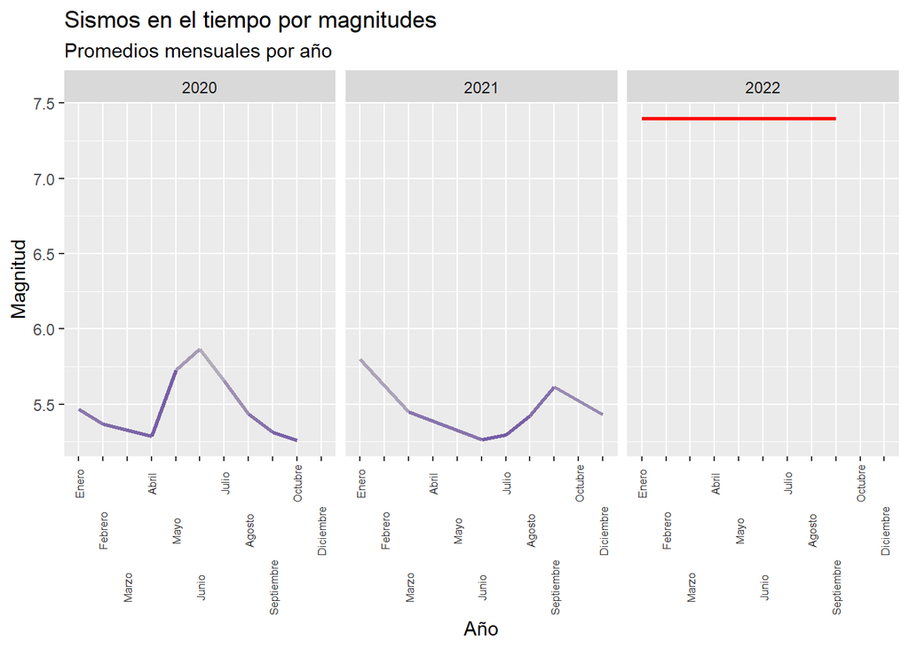

Sismos en la década de 2020 por magnitudes

Desafortunadamente este tipo de gráficos no resulven mucho el problema subjetivo porque todavía hay un margen de interpretación de los datos. Esto se puede mediamente calcular si sumamos los promedios mensuales y creamos un histograma por mes de modo que podamos ver qué sumatoria de promedios mensuales sobresale enter todos los meses. Esto reduce el margen interpretativo y nos indicará qué mes es aquel donde las intensidad de los sismos se incrementa. Recordemos, sin embargo, que siempre tiembla. Lo que haremos, por tanto es ver no cuándo tiembla más sino cuándo tiembla más fuerte.

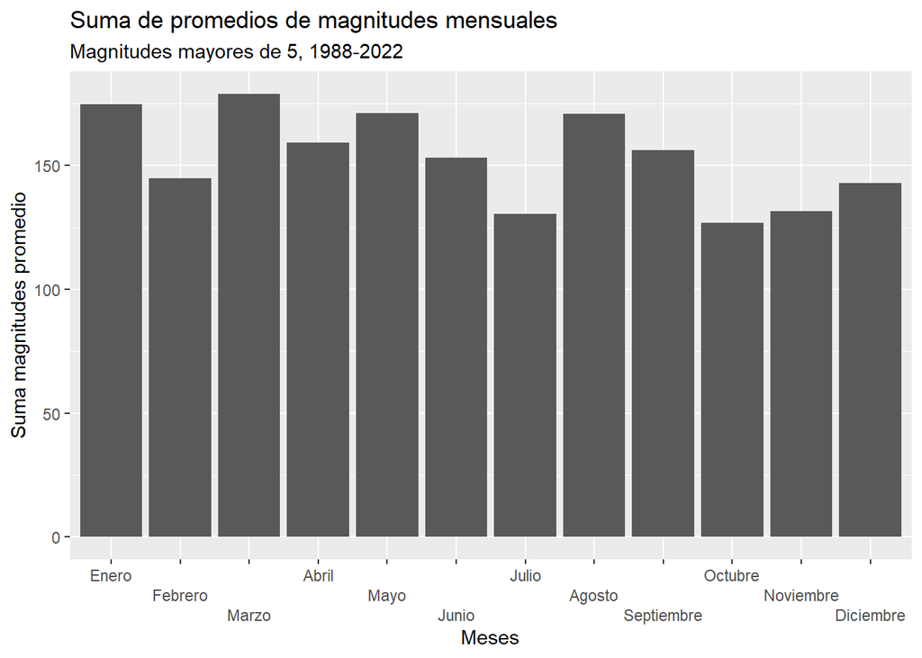

Suma de promedios de magnitudes mensuales mayores a 5 de magnitud desde 1988 a 2022

Si bien este reporte / análisis no es concluyente ni pretende mostrar que el realismo mágico tiene un componente real, sí intenta mostrar que existe potencialmente un estudio de caso geológico que podría ser estudiado con más calma y menos emociones cientificistas casi intolerantes a cualquier otro tipo de pensamiento. Es posible que sí exista un patrón y que este tipo de estudios aporten soluciones a la largo plazo o futuras generaciones en la comprohensión de los sismos y si no su predictabilidad, al menos su posible periodicidad o aumento de intensidad debido a factores que por ahora no han sido estudiados ampliamente como el clima, la cercanía de la Tierra al sol, los ciclos lunares, el aumento de temperatura global, los cambios de temperatura del lecho marino, la erosión, etcétera.

# References

CIRES. 2012. “Sistema de Alerta Sísmica Mexicano (SASMEX®).” http://cires.org.mx/sasmex_n.php.

México, Universidad Nacional Autónoma de México, Instituto de Geofísica, and Servicio Sismológico Nacional. 2022. “Catálogo de Sismos.” UNAM, IGEF, SSN. doi:10.21766/SSNMX/EC/MX.